# Tutorial 13: Multi-level models with pooled cross-sections

Forschungspraktikum I und II: Vergleichende Sozialforschung mit Mehrebenenmodellen in R

Dr. Christian Czymara (Sociology with Focus on Quantitative Methods for Social Research, Goethe University Frankfurt)

## 1. Preparation

### a) Packages

We will work with the following packages:

- `haven` (importing Stata data)
- `tidyverse` (various)
- `lme4` (multilevel models)
- `parameters` (demeaning)
- `sjPlot` (tables & figures)

Install and load them.

```r
packages <- c("haven", "lme4", "parameters", "sjPlot", "tidyverse")

# install if necessary
install.packages(setdiff(packages, rownames(installed.packages())))

# load
lapply(packages, library, character.only = TRUE)
```

[output not shown]

### b) Data

Import ESS678.dta and assign it to object `ESS678`.

```r
ESS678 <- read_dta("ESS678.dta")
```

## 2. Descriptive overview

How many observations are there in each wave? What is the average trust in politicians per year?

```r
table(ESS678$essround)
```

```
##
##     6     7     8
## 36116 32746 31890
```

```r
aggregate(ESS678$trstplt, by=list(ESS678$essround),mean)
```

```
##   Group.1        x
## 1       6 3.547015
## 2       7 3.721401
## 3       8 3.841957
```

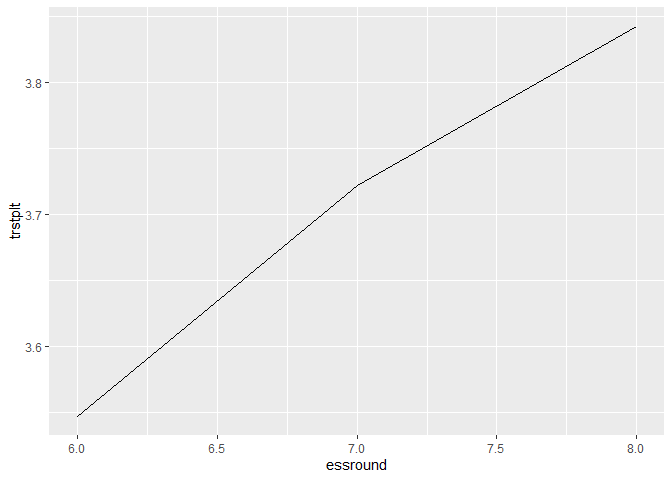

```r
ESS678 %>%
  ggplot(aes(x = essround,
             y = trstplt)) +
  stat_summary(aes(y = trstplt),
  fun=mean, geom="line")
```

```r
range(ESS678$trstplt)
```

```
## <labelled<double>[2]>: Trust in politicians
## [1]  0 10
##
## Labels:
##  value           label
##      0 No trust at all
##      1               1
##      2               2
##      3               3
##      4               4
##      5               5
##      6               6
##      7               7
##      8               8
##      9               9
##     10  Complete trust
```

## 3. Random effects models

### a) Cross-sectional models

We are interested in the relationship between trust in politicians and Corruption (`CPI`). In a first step, estimate one multi-level models (with individuals nested in `cntry2`) for each wave (indicated by `essround`). How large is this relationship? Is it stable over the three wave?

```r
m1_ess6 <- lmer(trstplt ~ CPI + (1 | cntry2),
                data = subset(ESS678, essround == 6))
m1_ess7 <- lmer(trstplt ~ CPI + (1 | cntry2),
                data = subset(ESS678, essround == 7))
m1_ess8 <- lmer(trstplt ~ CPI + (1 | cntry2),
                data = subset(ESS678, essround == 8))

tab_model(m1_ess6, m1_ess7, m1_ess8)
```

|  | Trust in politicians |  |  | Trust in politicians |  |  | Trust in politicians |  |  |
| --- | --- | --- | --- | --- | --- | --- | --- | --- | --- |
| Predictors | Estimates | CI | p | Estimates | CI | p | Estimates | CI | p |
| (Intercept) | -0.83 | -1.97 – 0.30 | 0.150 | -1.50 | -3.02 – 0.03 | 0.055 | -0.37 | -1.98 – 1.24 | 0.652 |
| Corruption Perception Index | 0.06 | 0.05 – 0.08 | **<0.001** | 0.07 | 0.05 – 0.09 | **<0.001** | 0.06 | 0.04 – 0.08 | **<0.001** |
| Random Effects |  |  |  |  |  |  |  |  |  |
| σ<sup>2</sup> | 4.49 |  |  | 4.80 |  |  | 4.79 |  |  |
| τ<sub>00</sub> | 0.37 <sub>cntry2</sub> |  |  | 0.34 <sub>cntry2</sub> |  |  | 0.40 <sub>cntry2</sub> |  |  |
| ICC | 0.08 |  |  | 0.07 |  |  | 0.08 |  |  |
| N | 23 <sub>cntry2</sub> |  |  | 20 <sub>cntry2</sub> |  |  | 20 <sub>cntry2</sub> |  |  |
| Observations | 36116 |  |  | 32746 |  |  | 31890 |  |  |
| Marginal R<sup>2</sup> / Conditional R<sup>2</sup> | 0.159 / 0.224 |  |  | 0.125 / 0.183 |  |  | 0.091 / 0.160 |  |  |

### b) Pooled model

Estimate a model based on the *pooled* data, including all three waves. There are now three levels of hierarchy: Individuals (level 1) nested in country-years (level 2, e. g.: Germany in 2008) nested in countries (level 3, e. g.: Germany). The following code will implement his random effects structure in `lmer()`: `(1 | cntry2/essround)`, see page 7 in the [vignette](https://cran.r-project.org/web/packages/lme4/vignettes/lmer.pdf). How large is the coefficient of corruption in the pooled data?

```r
m1_pooled <- lmer(trstplt ~ CPI
                + (1 | cntry2/essround),
                data = ESS678)

tab_model(m1_ess6, m1_ess7, m1_ess8, m1_pooled)
```

|  | Trust in politicians |  |  | Trust in politicians |  |  | Trust in politicians |  |  | Trust in politicians |  |  |
| --- | --- | --- | --- | --- | --- | --- | --- | --- | --- | --- | --- | --- |
| Predictors | Estimates | CI | p | Estimates | CI | p | Estimates | CI | p | Estimates | CI | p |
| (Intercept) | -0.83 | -1.97 – 0.30 | 0.150 | -1.50 | -3.02 – 0.03 | 0.055 | -0.37 | -1.98 – 1.24 | 0.652 | -0.15 | -1.18 – 0.88 | 0.774 |
| Corruption Perception Index | 0.06 | 0.05 – 0.08 | **<0.001** | 0.07 | 0.05 – 0.09 | **<0.001** | 0.06 | 0.04 – 0.08 | **<0.001** | 0.05 | 0.04 – 0.07 | **<0.001** |
| Random Effects |  |  |  |  |  |  |  |  |  |  |  |  |
| σ<sup>2</sup> | 4.49 |  |  | 4.80 |  |  | 4.79 |  |  | 4.69 |  |  |
| τ<sub>00</sub> | 0.37 <sub>cntry2</sub> |  |  | 0.34 <sub>cntry2</sub> |  |  | 0.40 <sub>cntry2</sub> |  |  | 0.07 <sub>essround:cntry2</sub> |  |  |
|  |  |  |  |  |  |  |  |  |  | 0.30 <sub>cntry2</sub> |  |  |
| ICC | 0.08 |  |  | 0.07 |  |  | 0.08 |  |  | 0.07 |  |  |
| N | 23 <sub>cntry2</sub> |  |  | 20 <sub>cntry2</sub> |  |  | 20 <sub>cntry2</sub> |  |  | 3 <sub>essround</sub> |  |  |
|  |  |  |  |  |  |  |  |  |  | 25 <sub>cntry2</sub> |  |  |
| Observations | 36116 |  |  | 32746 |  |  | 31890 |  |  | 100752 |  |  |
| Marginal R<sup>2</sup> / Conditional R<sup>2</sup> | 0.159 / 0.224 |  |  | 0.125 / 0.183 |  |  | 0.091 / 0.160 |  |  | 0.093 / 0.159 |  |  |

### c) Add individual-level controls

Add the individual level variables satisfaction with the economy (`stfeco`), feeling of household income (`hincfel`, categorical), and political orientation (`lrscale`) to the model of 3.b). Is the coefficient of corruption stable?

```r
m2_ind <- lmer(trstplt ~ CPI +
                 lrscale + stfeco + factor(hincfel)
                + (1 | cntry2/essround),
                data = ESS678)

summary(m2_ind, correlation = F)
```

```
## Linear mixed model fit by REML ['lmerMod']
## Formula:
## trstplt ~ CPI + lrscale + stfeco + factor(hincfel) + (1 | cntry2/essround)
##    Data: ESS678
##
## REML criterion at convergence: 421118
##
## Scaled residuals:
##     Min      1Q  Median      3Q     Max
## -3.6406 -0.6759 -0.0107  0.6782  4.7310
##
## Random effects:
##  Groups          Name        Variance Std.Dev.
##  essround:cntry2 (Intercept) 0.04167  0.2041
##  cntry2          (Intercept) 0.13299  0.3647
##  Residual                    3.81569  1.9534
## Number of obs: 100752, groups:  essround:cntry2, 63; cntry2, 25
##
## Fixed effects:
##                   Estimate Std. Error t value
## (Intercept)       0.026123   0.363844   0.072
## CPI               0.023394   0.005126   4.564
## lrscale           0.020338   0.002849   7.138
## stfeco            0.436465   0.003139 139.048
## factor(hincfel)2 -0.201447   0.014979 -13.448
## factor(hincfel)3 -0.326144   0.020667 -15.781
## factor(hincfel)4 -0.440955   0.031324 -14.077
```

## 4. Fixed effects models

Up to now, we had a look at the association between trust in politicians and corruption for all individuals in all countries for all waves. This means that the association in the model of 3.c) is based on a mixture of time-stable variance *between* countries and time-varying variance *within* countries over time (and individual-level variance, hence the three levels). This implies that we can eliminate all time stable differences (all variance on level 3) from the model and focus on changes within countries. There are two ways to do this:

### a) Country dummies

The first way to remove differences between countries is directly controlling for them by adding country dummy variables (also called *country fixed effects*). Run the model of 3.c) and add country fixed effects (i.e. add `cntry2` as a categorical variable). This model automatically controls for all time constant differences between countries and is based only on variance within countries over time. Focus on the country-variables and interpret the results. Do the conclusions differ compared to the model of 3.c)?

```r
m3_country_fe <- lmer(trstplt ~ CPI +
                 lrscale + stfeco + factor(hincfel)
                 + factor(cntry2)
                + (1 | cntry2/essround),
                data = ESS678)

tab_model(m3_country_fe)
```

|  | Trust in politicians |  |  |
| --- | --- | --- | --- |
| Predictors | Estimates | CI | p |
| (Intercept) | 1.61 | -1.20 – 4.42 | 0.260 |
| Corruption Perception Index | -0.00 | -0.03 – 0.03 | 0.915 |
| Placement on left right scale | 0.02 | 0.01 – 0.03 | **<0.001** |
| How satisfied with present state of economy in country | 0.44 | 0.43 – 0.44 | **<0.001** |
| factor(hincfel)2 | -0.20 | -0.23 – -0.17 | **<0.001** |
| factor(hincfel)3 | -0.33 | -0.37 – -0.29 | **<0.001** |
| factor(hincfel)4 | -0.44 | -0.50 – -0.38 | **<0.001** |
| factor(cntry2)3 | 0.60 | -1.68 – 2.88 | 0.605 |
| factor(cntry2)4 | -0.34 | -2.85 – 2.17 | 0.791 |
| factor(cntry2)5 | 0.75 | -1.56 – 3.06 | 0.524 |
| factor(cntry2)6 | 0.37 | -1.95 – 2.68 | 0.756 |
| factor(cntry2)7 | -0.35 | -2.74 – 2.05 | 0.777 |
| factor(cntry2)8 | -0.24 | -2.52 – 2.05 | 0.840 |
| factor(cntry2)9 | 1.03 | -1.31 – 3.38 | 0.388 |
| factor(cntry2)10 | 0.11 | -2.17 – 2.39 | 0.924 |
| factor(cntry2)11 | -0.46 | -2.77 – 1.85 | 0.695 |
| factor(cntry2)12 | 0.98 | -1.35 – 3.30 | 0.412 |
| factor(cntry2)13 | 0.17 | -2.11 – 2.44 | 0.886 |
| factor(cntry2)14 | 0.23 | -2.04 – 2.51 | 0.841 |
| factor(cntry2)15 | 0.33 | -2.04 – 2.70 | 0.784 |
| factor(cntry2)16 | 0.13 | -2.15 – 2.41 | 0.912 |
| factor(cntry2)18 | 0.60 | -1.69 – 2.89 | 0.606 |
| factor(cntry2)19 | -0.55 | -3.01 – 1.90 | 0.659 |
| factor(cntry2)20 | 0.17 | -2.16 – 2.50 | 0.886 |
| factor(cntry2)21 | 1.12 | -1.17 – 3.42 | 0.338 |
| factor(cntry2)22 | 0.46 | -1.85 – 2.76 | 0.696 |
| factor(cntry2)23 | -1.01 | -3.32 – 1.31 | 0.394 |
| factor(cntry2)24 | -0.50 | -2.80 – 1.80 | 0.671 |
| factor(cntry2)26 | 0.69 | -1.63 – 3.01 | 0.559 |
| factor(cntry2)27 | -0.47 | -2.78 – 1.84 | 0.691 |
| factor(cntry2)28 | -0.14 | -2.59 – 2.31 | 0.911 |
| Random Effects |  |  |  |
| σ<sup>2</sup> | 3.82 |  |  |
| τ<sub>00</sub> <sub>essround:cntry2</sub> | 0.04 |  |  |
| τ<sub>00</sub> <sub>cntry2</sub> | 0.66 |  |  |
| ICC | 0.15 |  |  |
| N <sub>essround</sub> | 3 |  |  |
| N <sub>cntry2</sub> | 25 |  |  |
| Observations | 100752 |  |  |
| Marginal R<sup>2</sup> / Conditional R<sup>2</sup> | 0.296 / 0.405 |  |  |

### b) Demeaning

The second way to remove time-stable between variance is to center the `CPI` at its (time-invariant) country-specific mean. This procedure is also called demeaning (or *fixed effects transformation*).

Of course, there is a function that does this for us: `demean()` of the `parameters` package. Demean the `CPI` variable (by group `cntry2`). The resulting `CPI_within` is the version of `CPI` that only consists of variation within countries over time.

```r
CPI_demeaned <- demean(ESS678,
  select = "CPI",
  group = "cntry2")

ESS678$CPI_within <- CPI_demeaned$CPI_within
```

### c) Within effects

Replace `CPI` in the model of 3.c) with its demeaned version `CPI_within` (but do not change anything else, also do not include country dummies). Compare the coefficient of `CPI_within` in this model to the coefficient of `CPI` in the model of 4.a).

```r
lm3_demeaned <-  lmer(trstplt ~ CPI_within +
                        lrscale + stfeco + factor(hincfel)
                      + (1 | cntry2/essround),
                      data = ESS678)

# compare
tab_model(m3_country_fe, lm3_demeaned,
          dv.labels = c("Country FE","Demeaned FE"))
```

|  | Country FE |  |  | Demeaned FE |  |  |
| --- | --- | --- | --- | --- | --- | --- |
| Predictors | Estimates | CI | p | Estimates | CI | p |
| (Intercept) | 1.61 | -1.20 – 4.42 | 0.260 | 1.64 | 1.43 – 1.86 | **<0.001** |
| Corruption Perception Index | -0.00 | -0.03 – 0.03 | 0.915 |  |  |  |
| Placement on left right scale | 0.02 | 0.01 – 0.03 | **<0.001** | 0.02 | 0.01 – 0.03 | **<0.001** |
| How satisfied with present state of economy in country | 0.44 | 0.43 – 0.44 | **<0.001** | 0.44 | 0.43 – 0.44 | **<0.001** |
| factor(hincfel)2 | -0.20 | -0.23 – -0.17 | **<0.001** | -0.20 | -0.23 – -0.17 | **<0.001** |
| factor(hincfel)3 | -0.33 | -0.37 – -0.29 | **<0.001** | -0.33 | -0.37 – -0.29 | **<0.001** |
| factor(hincfel)4 | -0.44 | -0.50 – -0.38 | **<0.001** | -0.44 | -0.50 – -0.38 | **<0.001** |
| factor(cntry2)3 | 0.60 | -1.68 – 2.88 | 0.605 |  |  |  |
| factor(cntry2)4 | -0.34 | -2.85 – 2.17 | 0.791 |  |  |  |
| factor(cntry2)5 | 0.75 | -1.56 – 3.06 | 0.524 |  |  |  |
| factor(cntry2)6 | 0.37 | -1.95 – 2.68 | 0.756 |  |  |  |
| factor(cntry2)7 | -0.35 | -2.74 – 2.05 | 0.777 |  |  |  |
| factor(cntry2)8 | -0.24 | -2.52 – 2.05 | 0.840 |  |  |  |
| factor(cntry2)9 | 1.03 | -1.31 – 3.38 | 0.388 |  |  |  |
| factor(cntry2)10 | 0.11 | -2.17 – 2.39 | 0.924 |  |  |  |
| factor(cntry2)11 | -0.46 | -2.77 – 1.85 | 0.695 |  |  |  |
| factor(cntry2)12 | 0.98 | -1.35 – 3.30 | 0.412 |  |  |  |
| factor(cntry2)13 | 0.17 | -2.11 – 2.44 | 0.886 |  |  |  |
| factor(cntry2)14 | 0.23 | -2.04 – 2.51 | 0.841 |  |  |  |
| factor(cntry2)15 | 0.33 | -2.04 – 2.70 | 0.784 |  |  |  |
| factor(cntry2)16 | 0.13 | -2.15 – 2.41 | 0.912 |  |  |  |
| factor(cntry2)18 | 0.60 | -1.69 – 2.89 | 0.606 |  |  |  |
| factor(cntry2)19 | -0.55 | -3.01 – 1.90 | 0.659 |  |  |  |
| factor(cntry2)20 | 0.17 | -2.16 – 2.50 | 0.886 |  |  |  |
| factor(cntry2)21 | 1.12 | -1.17 – 3.42 | 0.338 |  |  |  |
| factor(cntry2)22 | 0.46 | -1.85 – 2.76 | 0.696 |  |  |  |
| factor(cntry2)23 | -1.01 | -3.32 – 1.31 | 0.394 |  |  |  |
| factor(cntry2)24 | -0.50 | -2.80 – 1.80 | 0.671 |  |  |  |
| factor(cntry2)26 | 0.69 | -1.63 – 3.01 | 0.559 |  |  |  |
| factor(cntry2)27 | -0.47 | -2.78 – 1.84 | 0.691 |  |  |  |
| factor(cntry2)28 | -0.14 | -2.59 – 2.31 | 0.911 |  |  |  |
| Corruption Perception Index |  |  |  | -0.00 | -0.03 – 0.03 | 0.938 |
| Random Effects |  |  |  |  |  |  |
| σ<sup>2</sup> | 3.82 |  |  | 3.82 |  |  |
| τ<sub>00</sub> | 0.04 <sub>essround:cntry2</sub> |  |  | 0.04 <sub>essround:cntry2</sub> |  |  |
|  | 0.66 <sub>cntry2</sub> |  |  | 0.27 <sub>cntry2</sub> |  |  |
| ICC | 0.15 |  |  | 0.08 |  |  |
| N | 3 <sub>essround</sub> |  |  | 3 <sub>essround</sub> |  |  |
|  | 25 <sub>cntry2</sub> |  |  | 25 <sub>cntry2</sub> |  |  |
| Observations | 100752 |  |  | 100752 |  |  |
| Marginal R<sup>2</sup> / Conditional R<sup>2</sup> | 0.296 / 0.405 |  |  | 0.237 / 0.295 |  |  |

In sum, what can you conclude about the relationship between the Corruption Perception Index and individual trust in politicians?

Controlling for all potential time stable differences is a huge advantage for the identification of causal effects. This has only been a quick rush through the principles of the fixed effects estimator. In case you are hooked, attend my research training on panel data analysis in the summer term 🙂